# Observation-level burn-probability model — design

From the canonical-team term set to the reduced 129-term elastic-net design (MapBiomas Argentina Fuego, Collection 1, step 02)

Author

Iván Barberá

Published

June 22, 2026

## 0.1 What this notebook is

This is the single, end-to-end record of how the Collection-1 observation-level burn-probability model was designed. The story runs in one direction:

1. **Term design (the greedy start).** We first wrote down the *maximal* design we were willing to evaluate in Google Earth Engine — the **canonical-team set, 427 terms**: 21 focal spectral features, 40 previous-year MapBiomas-mosaic bands, and six interaction blocks built on top of them. The strategy was deliberately greedy: give the elastic net as much flexibility as the GEE compute budget allows and let regularization sort it out.
2. **The convergence problem.** `glmnet`’s elastic-net path was *slow to converge* on that design. The diagnosis below shows the cause was **numerical, not statistical**: a heavily collinear design matrix makes coordinate descent crawl in the ill-conditioned low-$\lambda$ tail.
3. **The reduction protocol.** We then reduced the design from **427 → 129 terms** with a specific, reproducible protocol — pairwise-correlation pruning, an exact-linear- combination argument (which is how MIRBI and the tasseled-cap trio leave), a multivariate VIF screen, and a final fitting-config fix. Everything in Part III below **runs on the full 5.72M-observation training set at render time**.
4. **The final design + fitting config**, matching `workflow/02-model_fitting.R` term-for-term (that script is the source of truth).

> **This notebook renders on the full data.** The correlation, separability, eigenvalue, and VIF chunks read all five region tables (`collection-01/data/training_observations_*_v1.csv`, ~3.8 GB, ~5.72M obs) and compute on the complete set. It is therefore a heavy render (several minutes, several GB of RAM). The big matrices are `rm()`-ed and `gc()`-ed between sections to keep the peak bounded.

# 1 Part I — Term design (the greedy start)

## 1.1 Scope and motivation

MapBiomas Argentina Fuego Collection 1 produces annual burned-area maps for all of Argentina over 1999–2025 using Landsat C2 SR. The pipeline relies on a per-observation (pixel-date) burn-probability classifier evaluated for **every Landsat scene** intersecting the territory and the time window. That prediction step is the cost driver: the model is applied many billions of times, so the structure must be **cheap to evaluate** in GEE.

Collection 0 (Patagonia pilot) used a logistic regression with 40 terms per vegetation type, four fire-relevant indices (NBR, NBR2, MIRBI, NDVI), and a hand-picked interaction set that included custom annual min/max summaries and $\Delta$ values. Collection 1 keeps logistic regression — for the same compute reasons — but rebalances the design:

- **More focal flexibility**: many spectral features per observation instead of 4.
- **Previous-year context from MapBiomas**: replace custom-computed annual summaries with the official MapBiomas Argentina annual mosaic of year $y-1$, which provides phenologically informed composites at no extra preprocessing cost.
- **No deltas**: with rich pairwise interactions, monotonic effects and the inherent non-linearity of the logistic link absorb most of what $\Delta$ terms did in Collection 0. A 2-way interaction in $\eta$ already implies a roughly 3-way effect on the predicted probability.
- **Flexibility over interpretability**: this model is for prediction, not inference. Collinearity is acceptable *in principle* and addressed by an elastic-net fit (tuning both $\lambda$ and $\alpha$). The catch — that “acceptable” collinearity still has to be *fittable* in finite time — is the entire subject of Part II.
- **Stratification**: one model per **region × vegetation type** (using the MapBiomas LULC of year $y-1$, reclassified into a few coarse fire-classes), as in Collection 0.

## 1.2 Why the MapBiomas annual mosaic (instead of custom summaries)

In Collection 0 we computed our own per-pixel annual minimum and maximum of each fire index with a robust order-statistic rule. That was viable for one region × four indices but does not scale: doing the same over all of Argentina, for two years per focal year ($y-1$ in addition to $y$), with many more features, would multiply preprocessing cost considerably.

The MapBiomas Argentina annual mosaic already provides, for every year, a coherent set of pixel-level composites:

- median, dry-season median, wet-season median, minimum, and within-year standard deviation of the six optical bands;
- the same statistics for a broad set of vegetation and fire-relevant indices (NDVI, NDWI, EVI2, SAVI, GCVI, NDFI, SEFI, WEFI, …);
- SMA endmember fractions (GV, GVS, NPV, soil, shade, cloud);
- topographic information.

Using this mosaic instead of recomputing custom summaries removes a heavy preprocessing step, ensures consistency with the LULC product used for stratification, offers seasonal composites (wet, dry) we never had in Collection 0, and provides physically interpretable derived layers (NPV as a fuel-load proxy, NDFI as a fire/disturbance signal). The trade-off: we cannot freely define the summaries; we choose among what the mosaic exposes.

## 1.3 Which previous-year summaries (median, wet, sd — and the dry debate)

A previous-year summary is useful only insofar as it describes the **stable spectral state** of the pixel — the baseline against which the focal observation is compared. Summaries that move sharply when the pixel itself was disturbed in $y-1$ are confounded by exactly the kind of signal we want to detect later.

| Subscript | Meaning |
| --- | --- |
| $X_t$ | Value of feature $X$ at the focal observation (pixel-date) |
| $X_{\text{med}}$ | MapBiomas mosaic **median** of $X$ in year $y(t) - 1$ |
| $X_{\text{wet}}$ | MapBiomas mosaic **wet-season median** of $X$ in year $y(t) - 1$ |
| $X_{\text{dry}}$ | MapBiomas mosaic **dry-season median** of $X$ in year $y(t) - 1$ |
| $X_{\text{sd}}$ | MapBiomas mosaic **within-year standard deviation** of $X$ in year $y(t) - 1$ |

The canonical-team design carried **all four** summaries ($\text{med}, \text{wet}, \text{dry}, \text{sd}$). The reasoning for and against each:

- $\text{med}$ — robust central tendency. Insensitive to a single fire event unless the fire affected a large fraction of the year’s images. **Keep.**
- $\text{wet}$ — median of wet-season images. The wet season precedes the fire season, so a fire in $y-1$ generally occurs *after* the wet composite is laid down: the most fire-robust baseline in the mosaic. **Keep.**
- $\text{sd}$ — within-year variability. Contextualizes change: pixels with naturally high $\text{sd}$ should be judged against a more permissive burn threshold. **Keep.**
- $\text{dry}$ — the dry season *is* the fire season, so a $y-1$ fire contaminates the dry composite in the *same direction* as the future fire we want to detect (dry NDVI drops, dry SWIR rises). For pixels that did **not** burn in $y-1$ (the majority) it still carries peak- senescence / end-of-season fuel signal, so the canonical-team set kept it and let the net decide. In the reduction (Part III) it is dropped from the **interaction** blocks (kept only as a main effect) because it is partly redundant with $\text{med}$ and risks bias on previously-burned pixels.

We never used $\text{amp}$ (max − min, inflated by either fire or normal phenology) or bare $\text{min}$/$\text{max}$ (which only supported $\Delta$ features we dropped).

## 1.4 Spectral feature equations

The base focal feature set is **17 features** (six optical bands + 11 indices); the canonical-team proposal extends this to **21** by adding AFRI, kNDVI, EVI2, NIRv.

| Group | Feature | Definition |
| --- | --- | --- |
| Optical | BLUE, GREEN, RED, NIR, SWIR1, SWIR2 | Surface-reflectance bands |
| Fire | $\text{NBR}$ | $(\text{NIR} - \text{SWIR2}) / (\text{NIR} + \text{SWIR2})$ |
| Fire | $\text{NBR2}$ | $(\text{SWIR1} - \text{SWIR2}) / (\text{SWIR1} + \text{SWIR2})$ |
| Fire | $\text{MIRBI}$ | $10\,\text{SWIR2} - 9.8\,\text{SWIR1} + 2$ |
| Fire | $\text{NDVI}$ | $(\text{NIR} - \text{RED}) / (\text{NIR} + \text{RED})$ |
| Tasseled-cap | $\text{TCB}$ | $0.3029\,\text{BLUE} + 0.2786\,\text{GREEN} + 0.4733\,\text{RED} + 0.5599\,\text{NIR} + 0.5080\,\text{SWIR1} + 0.1872\,\text{SWIR2}$ |
| Tasseled-cap | $\text{TCG}$ | $-0.2941\,\text{BLUE} - 0.2430\,\text{GREEN} - 0.5424\,\text{RED} + 0.7276\,\text{NIR} + 0.0713\,\text{SWIR1} - 0.1608\,\text{SWIR2}$ |
| Tasseled-cap | $\text{TCW}$ | $0.1511\,\text{BLUE} + 0.1973\,\text{GREEN} + 0.3283\,\text{RED} + 0.3407\,\text{NIR} - 0.7117\,\text{SWIR1} - 0.4559\,\text{SWIR2}$ |
| Aux. moisture | $\text{NDMI}$ | $(\text{NIR} - \text{SWIR1}) / (\text{NIR} + \text{SWIR1})$ |
| Aux. snow | $\text{NDSI}$ | $(\text{GREEN} - \text{SWIR1}) / (\text{GREEN} + \text{SWIR1})$ |
| Aux. sparse veg | $\text{SAVI}$ | $[(\text{NIR} - \text{RED}) / (\text{NIR} + \text{RED} + L)]\,(1 + L)$, $L = 0.5$ |
| Aux. open water | $\text{NDWI}$ | $(\text{GREEN} - \text{NIR}) / (\text{GREEN} + \text{NIR})$ |
| Aux. aerosol-free | $\text{AFRI}$ | $(\text{NIR} - 0.5\,\text{SWIR2}) / (\text{NIR} + 0.5\,\text{SWIR2})$ |
| Aux. veg. kernel | $\text{kNDVI}$ | $\tanh(\text{NDVI}^2)$ |
| Aux. enhanced veg | $\text{EVI2}$ | $2.5\,(\text{NIR} - \text{RED}) / (\text{NIR} + 2.4\,\text{RED} + 1)$ |
| Aux. NIR veg | $\text{NIRv}$ | $\text{NIR} \times \text{NDVI}$ |

Notes: tasseled-cap coefficients are Baig et al. (2014) for Landsat 8 OLI. MIRBI is in the raw Trigg & Flasse (2001) orientation; it *increases* after fire (opposite sign of NBR, NBR2, NDVI). NDWI here is McFeeters (1996), distinct from NDMI (Gao 1996). AFRI is AFRI-2100 (Karnieli et al. 2001, Eq. 11a); kNDVI uses the RBF-kernel form (Camps-Valls et al. 2021); EVI2 is the blue-band- free EVI (Jiang et al. 2008); NIRv is Badgley et al. (2017).

**Note two facts that drive the whole reduction in Part III:**

- $\text{MIRBI} = 10\,\text{SWIR2} - 9.8\,\text{SWIR1} + 2$ is an **exact linear function** of two raw bands we keep.
- $\text{TCB}, \text{TCG}, \text{TCW}$ are **exact linear functions** of the six raw bands.
- $\text{NBR}, \text{NBR2}, \text{NDMI}$ are **ratios** of pairs of raw bands — *near*-functions of them (nonlinear, so not exact, but strongly collinear).

Previous-year variables beyond the six optical bands, taken directly from the mosaic: NDVI and NDWI (same formulas as focal), NPV (non-photosynthetic vegetation fraction from SMA — fine-fuel proxy), and NDFI (Normalized Difference Fraction Index, Souza et al. 2005 — disturbance signal).

## 1.5 The canonical-team design — 427 terms

The linear predictor is
$$\Pr(y_{c,t} = 1) = \sigma\!\Big(\alpha_{k[c]} + \sum_{j} \beta_{j,k[c]}\, x_{j,c,t}\Big),$$
with $k[c]$ the vegetation cluster of pixel $c$ in year $y-1$ and $\sigma$ the logistic function. The canonical-team set organizes the terms into six blocks:

| Block | Description | Count |
| --- | --- | --- |
| 1 | Focal raw (21 features) | 21 |
| 2 | Prev-year raw (10 vars × 4 summaries) | 40 |
| 3 | Focal × focal pairwise, $\binom{21}{2}$ | 210 |
| 4 | Same-band prev × focal (8 vars × 4 summaries) | 32 |
| 5 | Prev context × focal fire **indices** ($4\times4\times4 - 4$) | 60 |
| 6 | Prev context × focal fire **bands** ($4\times4\times4$) | 64 |
|  | **Total** | **427** |

The modeling claim behind blocks 5–6 is that **the meaning of a focal fire-index value depends on the previous-year vegetation context**: a low $\text{NBR}_t$ in a high-NPV, low-NDFI pixel (heavy dead biomass, recently disturbed) is far more likely to be fire than the same $\text{NBR}_t$ in a low-NPV, high-NDFI pixel. Block 3 (the 210 focal pairs) carries most of the raw flexibility. This was the greedy maximum: maximal expressiveness within a ~15-node GEE graph (see §[GEE]). The problem was getting it to *fit*.

# 2 Part II — The convergence problem

`02-model_fitting.R`’s elastic-net search was **slow to converge** on the 427-term design — some classes took many hours per $\alpha$, occasionally not finishing. Two hypotheses:

- **Statistical**: not enough signal / too many obs, intrinsically hard problem.
- **Numerical**: the design matrix is so collinear that `glmnet`’s coordinate descent crawls in the ill-conditioned, low-$\lambda$ tail (where the active set is large), and a coarse $\lambda$ grid gives poor warm starts.

The leading suspect was numerical. The canonical-team design expands 21 focal features + 40 mosaic bands into 427 terms via pairwise products and curated crosses. **If the raw inputs are already strongly correlated, every interaction block inherits and amplifies that redundancy** — products of collinear factors are even more collinear than the factors. Coordinate descent on a near-singular Gram matrix converges geometrically slowly.

Part III tests that hypothesis directly (it is correct) and acts on it in two ways: **remove the *removable* redundancy** (exact linear combinations and duplicated axes add columns but no information, so they only hurt conditioning) and **keep the *irreducible* redundancy** (bands + their ratio-indices are intentionally near-collinear; that residual is what the elastic-net **ridge** component, $\alpha<1$, is designed to absorb). The leftover knob — `glmnet`’s convergence tolerance — turns out to be the single biggest speed lever (§[Fitting]).

# 3 Part III — The collinearity-reduction protocol

Everything below executes on the full data. The protocol, in order:

## 3.1 Setup

```r
suppressPackageStartupMessages({
  library(data.table)
  library(corrplot)   # clustered correlation heatmaps
})

# Resolve repo root whether the working dir is repo root or collection-01/notebooks.
find_root <- function() {
  for (p in c(".", "..", "../..", "../../..")) {
    if (file.exists(file.path(p, "collection-01", "config", "veg_fire_remap.csv")))
      return(normalizePath(p))
  }
  stop("Could not locate repo root (collection-01/config/veg_fire_remap.csv not found).")
}
ROOT     <- find_root()
VERSION  <- "1"
REGIONS  <- c("BA", "CHACO", "PAMPA", "CUYO", "PAT")
obs_csv  <- function(reg) file.path(ROOT, "collection-01", "data",
              sprintf("training_observations_%s_v%s.csv", reg, VERSION))

# The full 21-focal / 40-prev canonical-team raw set — the STARTING point we reduce from.
FOCAL21 <- c("BLUE","GREEN","RED","NIR","SWIR1","SWIR2","NBR","NBR2","MIRBI","NDVI",
             "TCB","TCG","TCW","NDMI","NDSI","SAVI","NDWI","AFRI","kNDVI","EVI2","NIRv") # 21
PREV_VARS10 <- c("blue","green","red","nir","swir1","swir2","ndvi","ndwi","npv","ndfi") # 10
SUMM4       <- c("median", "median_wet", "median_dry", "stdDev")                         # 4
PREV40 <- as.vector(t(outer(PREV_VARS10, SUMM4,
            function(v, s) sprintf("mb_mos_%s_%s", v, s))))                              # 40
stopifnot(length(FOCAL21) == 21, length(PREV40) == 40)

COR_HI <- 0.90        # |r| threshold for "redundant" pair reporting / dropping
```

```r
# Read only the 61 raw columns (+ region) from all five tables; row-bind. The single slow step.
keep_cols <- c("region", FOCAL21, PREV40)
dt <- rbindlist(lapply(REGIONS, function(reg) {
  message("  reading ", basename(obs_csv(reg)), " ...")
  fread(obs_csv(reg), select = keep_cols)
}), use.names = TRUE)

cat(sprintf("Loaded %s obs x %d raw vars (%d focal + %d prev), regions: %s\n",
            format(nrow(dt), big.mark = ","), length(FOCAL21) + length(PREV40),
            length(FOCAL21), length(PREV40), paste(REGIONS, collapse = ", ")))
```

```
Loaded 5,724,753 obs x 61 raw vars (21 focal + 40 prev), regions: BA, CHACO, PAMPA, CUYO, PAT
```

```r
# Non-finite audit per group — high-NA columns distort any correlation.
na_summary <- function(cols) {
  s <- dt[, lapply(.SD, function(x) sum(!is.finite(x))), .SDcols = cols]
  data.table(var = cols, n_nonfinite = as.integer(unlist(s)),
             pct = round(100 * as.integer(unlist(s)) / nrow(dt), 3))[order(-n_nonfinite)]
}
cat("Focal group — non-finite counts (top 8):\n");        print(head(na_summary(FOCAL21), 8))
```

```
Focal group — non-finite counts (top 8):
```

```
      var n_nonfinite   pct
   <char>       <int> <num>
1:   BLUE           0     0
2:  GREEN           0     0
3:    RED           0     0
4:    NIR           0     0
5:  SWIR1           0     0
6:  SWIR2           0     0
7:    NBR           0     0
8:   NBR2           0     0
```

```r
cat("\nPrevious-year group — non-finite counts (top 8):\n"); print(head(na_summary(PREV40), 8))
```

```
Previous-year group — non-finite counts (top 8):
```

```
                       var n_nonfinite   pct
                    <char>       <int> <num>
1:      mb_mos_blue_median        2122 0.037
2:  mb_mos_blue_median_wet        2122 0.037
3:  mb_mos_blue_median_dry        2122 0.037
4:      mb_mos_blue_stdDev        2122 0.037
5:     mb_mos_green_median        2122 0.037
6: mb_mos_green_median_wet        2122 0.037
7: mb_mos_green_median_dry        2122 0.037
8:     mb_mos_green_stdDev        2122 0.037
```

### 3.1.1 Correlation helpers (big-data friendly)

`cor_fast` standardizes columns once and forms `crossprod / (n-1)` — a single BLAS matmul, far faster than per-pair `cor()` at millions of rows. Rows with any non-finite value in the group are dropped (complete-case *within the group*). `cor_spearman` ranks each column first (robust to the indices’ non-linearity). `find_redundant` is the iterative pairwise pruner from `caret::findCorrelation`, reimplemented.

```r
cor_fast <- function(M) {
  ok <- is.finite(rowSums(M)); M <- M[ok, , drop = FALSE]
  attr_n <- nrow(M); M <- scale(M)
  C <- crossprod(M) / (attr_n - 1)
  C[!is.finite(C)] <- NA
  attr(C, "n_used") <- attr_n
  C
}
cor_spearman <- function(M) {
  R <- apply(M, 2, function(x) frank(x, ties.method = "average", na.last = "keep"))
  cor_fast(R)
}
high_pairs <- function(C, thresh = 0) {
  ut <- which(upper.tri(C), arr.ind = TRUE)
  d  <- data.table(var1 = rownames(C)[ut[, 1]], var2 = colnames(C)[ut[, 2]], r = C[ut])
  d  <- d[is.finite(r)][abs(r) >= thresh][order(-abs(r))]
  d[, r := round(r, 3)][]
}
# Display-only sanitizer for corrplot: clamp tiny floating-point overshoot back into [-1,1]
# and zero out any non-finite cell (e.g. a near-zero-variance mosaic column). Does NOT touch
# the matrices used for the numeric tables above.
for_plot <- function(C) { C <- round(C, 6); C[!is.finite(C)] <- 0; pmax(pmin(C, 1), -1) }
# Greedy redundancy pruning. protect: never dropped. score: higher = keep (drops the
# lower-scoring member of the worst pair); if NULL, drops the higher-mean-|r| (globally
# more-redundant) member.
find_redundant <- function(C, thresh, protect = character(0), score = NULL) {
  A <- abs(C); diag(A) <- NA; drop <- character(0)
  repeat {
    keep <- setdiff(rownames(A), drop)
    sub  <- A[keep, keep, drop = FALSE]
    if (!any(sub > thresh, na.rm = TRUE)) break
    mx   <- which(sub == max(sub, na.rm = TRUE), arr.ind = TRUE)[1, ]
    cand <- keep[c(mx[1], mx[2])]; free <- setdiff(cand, protect)
    if (length(free) == 0L) { A[cand[1], cand[2]] <- A[cand[2], cand[1]] <- NA; next }
    if (length(free) == 1L) { drop <- c(drop, free); next }
    loser <- if (!is.null(score)) free[which.min(score[free])]
             else free[which.max(c(mean(sub[free[1], ], na.rm = TRUE),
                                   mean(sub[free[2], ], na.rm = TRUE)))]
    drop <- c(drop, loser)
  }
  drop
}
```

## 3.2 Step 1 — Focal mains (21 → 11)

```r
Mf  <- as.matrix(dt[, ..FOCAL21])
Cf_p <- cor_fast(Mf); Cf_s <- cor_spearman(Mf)
cat(sprintf("Focal Pearson computed on %s complete-case rows.\n",
            format(attr(Cf_p, "n_used"), big.mark = ",")))
```

```
Focal Pearson computed on 5,724,753 complete-case rows.
```

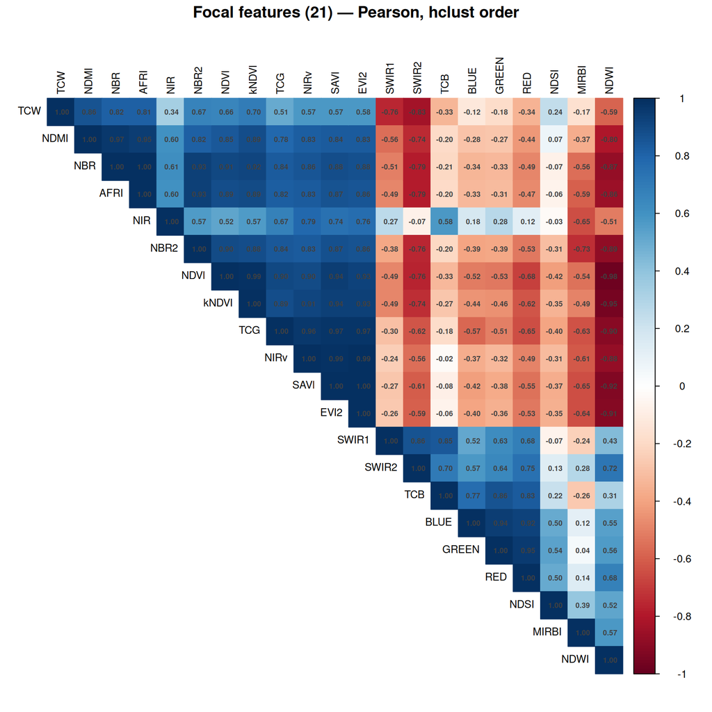

```r
corrplot(for_plot(Cf_p), method = "color", type = "upper", order = "hclust",
         addCoef.col = "grey25", number.cex = 0.55, tl.cex = 0.8, tl.col = "black",
         title = "Focal features (21) — Pearson, hclust order", mar = c(0, 0, 1.5, 0))
```

```r
cat("Focal — Pearson |r| >= ", COR_HI, ":\n", sep = ""); print(high_pairs(Cf_p, COR_HI))
```

```
Focal — Pearson |r| >= 0.9:
```

```
      var1   var2      r
    <char> <char>  <num>
 1:   SAVI   EVI2  0.999
 2:    NBR   AFRI  0.996
 3:   EVI2   NIRv  0.994
 4:   SAVI   NIRv  0.987
 5:   NDVI  kNDVI  0.986
 6:   NDVI   NDWI -0.977
 7:    TCG   SAVI  0.973
 8:    TCG   EVI2  0.971
 9:    NBR   NDMI  0.966
10:    TCG   NIRv  0.965
11:  GREEN    RED  0.955
12:   NDWI  kNDVI -0.954
13:   NDMI   AFRI  0.950
```

[output cut: 16 more lines]

```r
cat("\nFocal — Spearman |r| >= ", COR_HI, " (rank-based):\n", sep = ""); print(high_pairs(Cf_s, COR_HI))
```

```
Focal — Spearman |r| >= 0.9 (rank-based):
```

```
      var1   var2      r
    <char> <char>  <num>
 1:    NBR   AFRI  1.000
 2:   SAVI   EVI2  1.000
 3:   NDVI  kNDVI  1.000
 4:   EVI2   NIRv  0.999
 5:   SAVI   NIRv  0.998
 6:    TCG   SAVI  0.994
 7:    TCG   EVI2  0.994
 8:    TCG   NIRv  0.991
 9:   NDVI   NDWI -0.979
10:   NDWI  kNDVI -0.978
11:   NDMI   AFRI  0.955
12:    NBR   NDMI  0.955
13:    TCG   NDWI -0.949
```

[output cut: 28 more lines]

### 3.2.1 Univariate separability (burned vs unburned)

How well does each index *alone* separate burned from unburned? Headline is the **AUC** (Mann–Whitney, threshold-free): 0.5 = none, 1 = perfect; `sep` $= |\text{AUC}-0.5|\cdot 2$. This needs the `burned` label (absent from `dt`), so it does a fresh lightweight full read of `burned` + the 21 focal columns.

```r
sep_cols <- c("burned", FOCAL21)
sepdt <- rbindlist(lapply(REGIONS, function(reg) {
  message("  reading burned+focal from ", basename(obs_csv(reg)), " ...")
  fread(obs_csv(reg), select = sep_cols)
}), use.names = TRUE)

auc1 <- function(x, y) {
  ok <- is.finite(x); x <- x[ok]; y <- y[ok]
  n1 <- as.numeric(sum(y == 1L)); n0 <- as.numeric(sum(y == 0L))
  if (n1 == 0 || n0 == 0) return(NA_real_)
  r <- frank(x, ties.method = "average")
  (sum(r[y == 1L]) - n1 * (n1 + 1) / 2) / (n1 * n0)
}
yb  <- as.integer(sepdt$burned)
sep <- rbindlist(lapply(FOCAL21, function(f) {
  x  <- sepdt[[f]]; ok <- is.finite(x)
  a  <- auc1(x, yb)
  mb <- mean(x[ok & yb == 1L]); mu <- mean(x[ok & yb == 0L])
  vb <- var(x[ok & yb == 1L]);  vu <- var(x[ok & yb == 0L])
  n1 <- sum(ok & yb == 1L);     n0 <- sum(ok & yb == 0L)
  sp <- sqrt(((n1 - 1) * vb + (n0 - 1) * vu) / (n1 + n0 - 2))
  data.table(var = f, auc = a, sep = abs(a - 0.5) * 2,
             cohens_d = (mb - mu) / sp, mean_burned = mb, mean_unburned = mu)
}))
sep[, c("auc","sep","cohens_d","mean_burned","mean_unburned") :=
      .(round(auc,4), round(sep,4), round(cohens_d,3), round(mean_burned,4), round(mean_unburned,4))]
setorder(sep, -sep); print(sep)
```

```
       var    auc    sep cohens_d mean_burned mean_unburned
    <char>  <num>  <num>    <num>       <num>         <num>
 1:    NBR 0.1304 0.7391   -1.429     -0.0909        0.2544
 2:   AFRI 0.1304 0.7391   -1.598      0.2356        0.5282
 3:   NBR2 0.1306 0.7388   -1.537      0.0680        0.2285
 4:  MIRBI 0.8567 0.7133    1.562      1.8051        1.3395
 5:   NDMI 0.1733 0.6534   -1.123     -0.1567        0.0457
 6:    TCG 0.2006 0.5988   -0.856      0.0251        0.0835
 7:   NIRv 0.2161 0.5678   -0.788      0.0544        0.1158
 8:   EVI2 0.2206 0.5587   -0.845      0.1408        0.2590
 9:   SAVI 0.2220 0.5560   -0.869      0.1520        0.2679
10:    TCW 0.2320 0.5360   -1.002     -0.1415       -0.0843
11:    NIR 0.2385 0.5230   -0.870      0.1635        0.2254
12:  SWIR2 0.7590 0.5180    1.000      0.1967        0.1353
13:  kNDVI 0.2677 0.4646   -0.751      0.1179        0.2561
14:   NDVI 0.2679 0.4642   -0.788      0.3130        0.4787
15:   NDWI 0.7271 0.4543    0.778     -0.3973       -0.5151
16:   NDSI 0.4001 0.1997   -0.315     -0.5242       -0.4929
17:   BLUE 0.5938 0.1875    0.124      0.0490        0.0441
18:  SWIR1 0.5727 0.1453    0.234      0.2206        0.2055
19:    RED 0.5623 0.1246    0.123      0.0859        0.0796
20:    TCB 0.4673 0.0654   -0.113      0.3155        0.3267
21:  GREEN 0.4963 0.0075   -0.022      0.0701        0.0709
       var    auc    sep cohens_d mean_burned mean_unburned
```

```r
rm(sepdt); invisible(gc())
```

### 3.2.2 Automatic pruner (protect raw optical + NBR/NBR2; tiebreak by separability)

```r
KEEP_FOCAL <- c("NBR", "NBR2", "BLUE", "GREEN", "RED", "NIR", "SWIR1", "SWIR2")  # always keep
sep_score  <- setNames(sep$sep, sep$var)
drop_focal <- find_redundant(Cf_p, COR_HI, protect = KEEP_FOCAL, score = sep_score)
A <- abs(Cf_p); diag(A) <- NA
focal_summary <- data.table(
  var = FOCAL21, separability = round(sep_score[FOCAL21], 4),
  mean_abscor = round(rowMeans(A, na.rm = TRUE), 3),
  max_abscor  = round(apply(A, 1, max, na.rm = TRUE), 3))
focal_summary[, status := fifelse(var %in% KEEP_FOCAL, "protected",
                          fifelse(var %in% drop_focal, "DROP", "keep"))]
setorder(focal_summary, status, -separability); print(focal_summary)
```

```
       var separability mean_abscor max_abscor    status
    <char>        <num>       <num>      <num>    <char>
 1:   AFRI       0.7391       0.678      0.996      DROP
 2:   NDMI       0.6534       0.647      0.966      DROP
 3:   NIRv       0.5678       0.664      0.994      DROP
 4:   EVI2       0.5587       0.685      0.999      DROP
 5:   SAVI       0.5560       0.693      0.999      DROP
 6:  kNDVI       0.4646       0.716      0.986      DROP
 7:   NDVI       0.4642       0.731      0.986      DROP
 8:   NDWI       0.4543       0.721      0.977      DROP
 9:  MIRBI       0.7133       0.434      0.733      keep
10:    TCG       0.5988       0.697      0.973      keep
11:    TCW       0.5360       0.533      0.860      keep
12:   NDSI       0.1997       0.293      0.539      keep
13:    TCB       0.0654       0.373      0.861      keep
14:    NBR       0.7391       0.688      0.996 protected
15:   NBR2       0.7388       0.684      0.934 protected
16:    NIR       0.5230       0.474      0.789 protected
17:  SWIR2       0.5180       0.626      0.865 protected
18:   BLUE       0.1875       0.463      0.944 protected
19:  SWIR1       0.1453       0.465      0.865 protected
20:    RED       0.1246       0.569      0.955 protected
21:  GREEN       0.0075       0.474      0.955 protected
       var separability mean_abscor max_abscor    status
```

```r
cat("\nPairwise pruner DROP:", paste(drop_focal, collapse = ", "), "\n")
```

```
Pairwise pruner DROP: SAVI, AFRI, EVI2, NDVI, NDMI, NIRv, NDWI, kNDVI
```

### 3.2.3 The exact-linear-combination cut (MIRBI + tasseled-cap)

- **MIRBI** $= 10\,\text{SWIR2} - 9.8\,\text{SWIR1} + 2$ — exactly linear in two bands we keep.
- **TCB, TCG, TCW** — exact linear combinations of the six raw optical bands (Baig 2014).

With the raw bands protected, a linear model (and the band×· product terms) already **spans** these indices: regressing any of them on the bands gives $R^2 \approx 1$. They add columns and worsen conditioning but contribute no new direction. We verify the exactness two ways — an $R^2$ from the regression, and the **smallest eigenvalue of the relevant correlation submatrix**, which is the cleanest fingerprint of rank-deficiency (an exact linear dependence forces an **exactly zero** eigenvalue).

```r
r2_on <- function(y, xs) {                      # R^2 of y regressed on columns xs (complete cases)
  M <- as.matrix(dt[, c(y, xs), with = FALSE]); M <- M[is.finite(rowSums(M)), ]
  summary(lm(M[, 1] ~ M[, -1]))$r.squared
}
smallest_eig <- function(vars) {                # min eigenvalue of the correlation matrix
  C <- cor_fast(as.matrix(dt[, ..vars])); min(eigen(C, symmetric = TRUE)$values)
}
exact <- data.table(
  index   = c("MIRBI", "TCB", "TCG", "TCW"),
  spanned_by = c("SWIR1+SWIR2", "6 optical", "6 optical", "6 optical"),
  R2      = c(r2_on("MIRBI", c("SWIR1","SWIR2")),
              r2_on("TCB", c("BLUE","GREEN","RED","NIR","SWIR1","SWIR2")),
              r2_on("TCG", c("BLUE","GREEN","RED","NIR","SWIR1","SWIR2")),
              r2_on("TCW", c("BLUE","GREEN","RED","NIR","SWIR1","SWIR2"))))
exact[, R2 := round(R2, 6)]; print(exact)
```

```
    index  spanned_by    R2
   <char>      <char> <num>
1:  MIRBI SWIR1+SWIR2     1
2:    TCB   6 optical     1
3:    TCG   6 optical     1
4:    TCW   6 optical     1
```

```r
cat(sprintf("\nmin eigenvalue of cor(SWIR1, SWIR2, MIRBI)      = %.3e  (exact dependence -> ~0)\n",
            smallest_eig(c("SWIR1","SWIR2","MIRBI"))))
```

```
min eigenvalue of cor(SWIR1, SWIR2, MIRBI)      = -5.700e-13  (exact dependence -> ~0)
```

```r
cat(sprintf("min eigenvalue of cor(6 optical bands + TCB,TCG,TCW) = %.3e  (3 exact deps -> ~0)\n",
            smallest_eig(c("BLUE","GREEN","RED","NIR","SWIR1","SWIR2","TCB","TCG","TCW"))))
```

```
min eigenvalue of cor(6 optical bands + TCB,TCG,TCW) = -4.859e-13  (3 exact deps -> ~0)
```

$R^2 = 1$ (to floating-point) and a correlation eigenvalue at machine-epsilon confirm exact linear dependence: **drop MIRBI, TCB, TCG, TCW**. The ash/brightness signal TCB was prized for is not lost — TCB *is* a fixed weighted sum of the six protected bands, so the model retains full access to that contrast through the bands and their products.

### 3.2.4 Focal decision — the reduced 11

Combining the pruner with two manual rules (protect one greenness + one moisture index; prefer cheap normalized-difference indices over redundant ones) and the exact-combo cut:

**KEEP (11):** `BLUE GREEN RED NIR SWIR1 SWIR2` (raw optical) · `NBR NBR2` (burn) · **`NDVI`** (greenness) · **`NDMI`** (moisture) · `NDSI` (the one genuinely independent extra axis, max $|r|\approx0.54$).

**DROP (10):** `MIRBI TCB TCG TCW` (exact linear combos) · `AFRI kNDVI SAVI EVI2 NIRv` (greenness/ burn cluster, redundant with NDVI/NBR) · `NDWI` (McFeeters NDWI $\approx -$NDVI, $r=-0.977$: a greenness axis in disguise, not independent moisture).

Rationale highlights:

```r
FOCAL_KEEP <- c("BLUE","GREEN","RED","NIR","SWIR1","SWIR2","NBR","NBR2","NDVI","NDMI","NDSI") # 11
stopifnot(length(FOCAL_KEEP) == 11)
rm(Mf, Cf_p, Cf_s, A); invisible(gc())
cat("Focal mains kept (11):", paste(FOCAL_KEEP, collapse = ", "), "\n")
```

```
Focal mains kept (11): BLUE, GREEN, RED, NIR, SWIR1, SWIR2, NBR, NBR2, NDVI, NDMI, NDSI
```

## 3.3 Step 2 — Previous-year mains (40 → 32)

```r
Mp  <- as.matrix(dt[, ..PREV40]); Cp_p <- cor_fast(Mp)
cat(sprintf("Prev-year Pearson computed on %s complete-case rows.\n",
            format(attr(Cp_p, "n_used"), big.mark = ",")))
```

```
Prev-year Pearson computed on 5,722,631 complete-case rows.
```

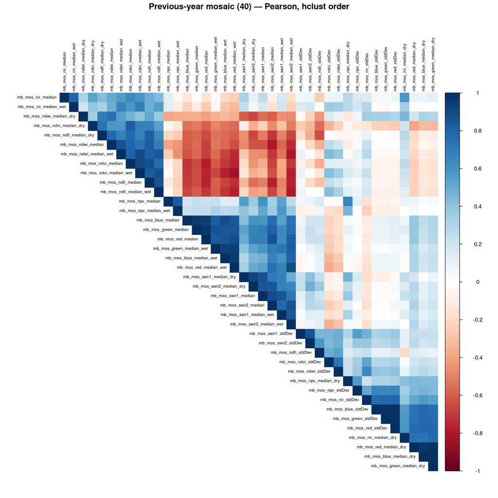

```r
corrplot(for_plot(Cp_p), method = "color", type = "upper", order = "hclust", tl.cex = 0.6, tl.col = "black",
         title = "Previous-year mosaic (40) — Pearson, hclust order", mar = c(0, 0, 1.5, 0))
```

```r
cat("Prev-year — Pearson |r| >= ", COR_HI, ":\n", sep = ""); print(high_pairs(Cp_p, COR_HI))
```

```
Prev-year — Pearson |r| >= 0.9:
```

```
                       var1                    var2     r
                     <char>                  <char> <num>
 1:     mb_mos_green_stdDev       mb_mos_red_stdDev 0.988
 2:      mb_mos_blue_stdDev     mb_mos_green_stdDev 0.987
 3:      mb_mos_blue_stdDev       mb_mos_red_stdDev 0.985
 4:  mb_mos_blue_median_dry mb_mos_green_median_dry 0.984
 5: mb_mos_green_median_dry   mb_mos_red_median_dry 0.982
 6:  mb_mos_blue_median_dry   mb_mos_red_median_dry 0.968
 7:     mb_mos_green_median       mb_mos_red_median 0.960
 8:      mb_mos_blue_median     mb_mos_green_median 0.957
 9:  mb_mos_blue_median_wet   mb_mos_red_median_wet 0.949
10:      mb_mos_blue_median       mb_mos_red_median 0.947
11: mb_mos_green_median_wet   mb_mos_red_median_wet 0.934
12:  mb_mos_blue_median_wet mb_mos_green_median_wet 0.930
13: mb_mos_swir1_median_dry mb_mos_swir2_median_dry 0.917
```

The prev-year set is far **less collinear than focal** — essentially all $>0.9$ redundancy is one structure: the **visible trio** (blue ≈ green ≈ red) are near-duplicates within *every* summary ($r\approx0.93$–$0.99$). The median/wet/dry/sd summaries of every other variable are distinct enough to keep.

**Decision — keep `green` as the single visible representative (all 4 summaries) and drop `blue` and `red` entirely (8 columns):** 8 base vars (`green, nir, swir1, swir2, ndvi, ndwi, npv, ndfi`) × 4 summaries = **32 main terms**. These are cheap, only mildly collinear main effects; we keep them generously. (Which prev bands enter the expensive *interaction* blocks is decided separately, in Step 4.)

```r
PREV_DROP_VARS <- c("blue", "red")
PREV_MAIN <- PREV40[!grepl(sprintf("mb_mos_(%s)_", paste(PREV_DROP_VARS, collapse = "|")), PREV40)]
stopifnot(length(PREV_MAIN) == 32)
rm(Mp, Cp_p); invisible(gc())
cat("Prev mains kept (32):\n"); print(PREV_MAIN)
```

```
Prev mains kept (32):
```

```
 [1] "mb_mos_green_median"     "mb_mos_green_median_wet"
 [3] "mb_mos_green_median_dry" "mb_mos_green_stdDev"
 [5] "mb_mos_nir_median"       "mb_mos_nir_median_wet"
 [7] "mb_mos_nir_median_dry"   "mb_mos_nir_stdDev"
 [9] "mb_mos_swir1_median"     "mb_mos_swir1_median_wet"
[11] "mb_mos_swir1_median_dry" "mb_mos_swir1_stdDev"
[13] "mb_mos_swir2_median"     "mb_mos_swir2_median_wet"
[15] "mb_mos_swir2_median_dry" "mb_mos_swir2_stdDev"
[17] "mb_mos_ndvi_median"      "mb_mos_ndvi_median_wet"
[19] "mb_mos_ndvi_median_dry"  "mb_mos_ndvi_stdDev"
[21] "mb_mos_ndwi_median"      "mb_mos_ndwi_median_wet"
[23] "mb_mos_ndwi_median_dry"  "mb_mos_ndwi_stdDev"
[25] "mb_mos_npv_median"       "mb_mos_npv_median_wet"
[27] "mb_mos_npv_median_dry"   "mb_mos_npv_stdDev"
[29] "mb_mos_ndfi_median"      "mb_mos_ndfi_median_wet"
[31] "mb_mos_ndfi_median_dry"  "mb_mos_ndfi_stdDev"
```

## 3.4 Step 3 — Focal × focal interactions (210 → 22)

With 11 focal mains the pairwise block is $\binom{11}{2}=55$ candidates (down from $\binom{21}{2}=210$). We keep an interaction only if it adds structure beyond the mains and the other kept interactions — pruning by correlation with the **11 mains protected**.

**Products are built from CENTERED factors**, $(X-\bar X)(Y-\bar Y)$, not raw $X\!\cdot\!Y$ — the only honest way to judge interaction redundancy, since a raw product is *mechanically* correlated with its parents. Centering the *factors* genuinely changes the column: $(X-a)(Y-b) = XY - aY - bX + ab$.

> **Is this just reparameterization?** Only without a penalty. In an unpenalized model that also holds $X$, $Y$ and an intercept, raw and centered products span the same space → identical predictions. **Under glmnet’s penalty it is a different model**: the penalty is on the coefficients, which differ between parameterizations for the same surface, so the penalized optimum (selection + shrinkage) differs — in the better-conditioned direction. For **deployment** the distinction vanishes: once fitted, fold the centering constants into the intercept + main slopes, and GEE deploys raw band products (no means vector).

```r
OPT_K <- c("BLUE","GREEN","RED","NIR","SWIR1","SWIR2")
IDX_K <- c("NBR","NBR2","NDVI","NDMI","NDSI")
Mk <- as.matrix(dt[, ..FOCAL_KEEP]); Mk <- Mk[is.finite(rowSums(Mk)), ]
Mc <- sweep(Mk, 2, colMeans(Mk), "-")                    # CENTER factors before multiplying
pr <- combn(FOCAL_KEEP, 2)                               # 55 distinct pairs
P  <- vapply(seq_len(ncol(pr)), function(k) Mc[, pr[1, k]] * Mc[, pr[2, k]], numeric(nrow(Mc)))
colnames(P) <- apply(pr, 2, paste, collapse = ":")
Cint     <- cor_fast(cbind(Mk[, FOCAL_KEEP], P))         # raw mains + centered products
drop_int <- find_redundant(Cint, COR_HI, protect = FOCAL_KEEP)
keep_int_pw <- setdiff(colnames(P), drop_int)
blk <- function(t) { ab <- strsplit(t, ":")[[1]]
  if (all(ab %in% OPT_K)) "opt:opt" else if (all(ab %in% IDX_K)) "idx:idx" else "opt:idx" }
itab <- data.table(term = colnames(P), block = vapply(colnames(P), blk, ""),
                   status = fifelse(colnames(P) %in% keep_int_pw, "keep", "DROP"))
cat(sprintf("Pairwise prune: kept %d / 55  (|r| > %.2f, 11 mains protected, centered factors)\n",
            length(keep_int_pw), COR_HI))
```

```
Pairwise prune: kept 25 / 55  (|r| > 0.90, 11 mains protected, centered factors)
```

```r
print(itab[, .(keep = sum(status == "keep"), total = .N), by = block][order(block)])
```

```
     block  keep total
    <char> <int> <int>
1: idx:idx     7    10
2: opt:idx    12    30
3: opt:opt     6    15
```

```r
rm(Mk, Mc, P, Cint); invisible(gc())
```

```r
FOCAL_INT <- c("BLUE:NBR","BLUE:NBR2","BLUE:NDMI","BLUE:RED","BLUE:SWIR1","GREEN:NIR",
               "NBR:NBR2","NBR:NDMI","NBR2:NDSI","NBR2:NDVI","NDMI:NDSI","NDVI:NDMI",
               "NDVI:NDSI","NIR:NBR","NIR:NDSI","NIR:SWIR1","NIR:SWIR2","SWIR1:NDMI",
               "SWIR1:NDSI","SWIR1:NDVI","SWIR1:SWIR2","SWIR2:NDVI")                  # 22
stopifnot(length(FOCAL_INT) == 22)
cat("Frozen focal interactions (22), used in fitting:\n"); print(FOCAL_INT)
```

```
Frozen focal interactions (22), used in fitting:
```

```
 [1] "BLUE:NBR"    "BLUE:NBR2"   "BLUE:NDMI"   "BLUE:RED"    "BLUE:SWIR1"
 [6] "GREEN:NIR"   "NBR:NBR2"    "NBR:NDMI"    "NBR2:NDSI"   "NBR2:NDVI"
[11] "NDMI:NDSI"   "NDVI:NDMI"   "NDVI:NDSI"   "NIR:NBR"     "NIR:NDSI"
[16] "NIR:SWIR1"   "NIR:SWIR2"   "SWIR1:NDMI"  "SWIR1:NDSI"  "SWIR1:NDVI"
[21] "SWIR1:SWIR2" "SWIR2:NDVI"
```

This is **22 vs the old 210** — the single biggest term-count cut.

## 3.5 Step 4 — Prev × focal interactions (curated B4–B6, median + sd → 64)

For prev × focal we keep the **curated block structure** rather than crossing everything: the blocks encode a *relevance* prior — a band interacts with its own previous-year level (same-band), and previous-year vegetation/fraction state modulates the fire signal — which a pure correlation prune would discard (it removes *redundant* terms, not *useless* ones). Two reductions vs the canonical-team blocks: each block uses the **median + sd** summaries only (dropping $\text{wet}\approx\text{med}$ and the partly-redundant $\text{dry}$ from the interactions), and block membership is aligned to the reduced main sets (11 focal, 32 prev).

| block | prev side (× med + sd) | × focal side | count |
| --- | --- | --- | --- |
| **B4 same-band** | green, nir, swir1, swir2, ndvi | each × its own focal band | 5 × 2 = **10** |
| **B5 idx × fire-idx** | ndvi, ndwi, npv, ndfi | × {NBR, NBR2, NDVI}; skip ndvi×NDVI | 4×3×2 − 2 = **22** |
| **B6 idx × fire-band** | ndvi, ndwi, npv, ndfi | × {RED, NIR, SWIR1, SWIR2} | 4×4×2 = **32** |
| **total** |  |  | **64** |

These blocks are **not** correlation-pruned among themselves — they are already a curated, sparse set. Their multivariate collinearity against the mains is checked next.

## 3.6 Step 5 — Multivariate collinearity (VIF) and the redundancy we keep on purpose

Pairwise correlation can’t see when a term is a linear combination of *several* others; VIF can: $\text{VIF}_j = 1/(1 - R^2_j)$, with $R^2_j$ from regressing term $j$ on all others ($>5$ moderate, $>10$ serious). It is **n-invariant** (a function of the correlation matrix only).

**The caveat that dominates here, and your question about the bands + ratio-indices.** We deliberately keep the 6 raw optical bands *and* indices that are (near-)functions of them: NBR, NBR2, NDMI are **ratios** of NIR/SWIR pairs. That makes the protected main set **intentionally near-rank-deficient** — `cor(X)` is numerically near-singular, and naïve `diag(solve(cor(X)))` returns garbage (VIFs in the millions). That collinearity is **not** a bug and is **not** removed by deleting terms; it is exactly what the **elastic-net ridge component ($\alpha<1$) absorbs**.

### 3.6.1 How you *see* near-rank-deficiency: eigenvalues of the correlation matrix

The clean diagnostic is the eigenvalue spectrum of the correlation matrix of the suspect block. For a set of $p$ standardized variables, $\sum\lambda_i = p$. An **exact** linear dependence forces a $\lambda_i = 0$; a **near** dependence forces a $\lambda_i \approx 0$. The condition number $\kappa = \lambda_{\max}/\lambda_{\min}$ measures how close to singular the block is ($\kappa \gtrsim 30$ is the usual flag; $\kappa \gtrsim 1000$ is severe).

Take the block you asked about — **{NBR, NBR2, NIR, SWIR1, SWIR2}**. NBR and NBR2 are ratios built from {NIR, SWIR1, SWIR2}, so five variables live in essentially **three** underlying dimensions: we expect the two smallest eigenvalues to collapse toward zero and $\kappa$ to be large.

```r
demo <- c("NBR","NBR2","NIR","SWIR1","SWIR2")
Cd   <- cor_fast(as.matrix(dt[, ..demo]))
ed   <- eigen(Cd, symmetric = TRUE)$values
print(data.table(component = seq_along(ed),
                 eigenvalue = round(ed, 5),
                 pct_var = round(100 * ed / sum(ed), 2),
                 cum_pct = round(100 * cumsum(ed) / sum(ed), 2)))
```

```
   component eigenvalue pct_var cum_pct
       <int>      <num>   <num>   <num>
1:         1    3.26925   65.38   65.38
2:         2    1.50343   30.07   95.45
3:         3    0.17891    3.58   99.03
4:         4    0.03495    0.70   99.73
5:         5    0.01346    0.27  100.00
```

```r
cat(sprintf("\nsum of eigenvalues = %.2f (= p = %d)\n", sum(ed), length(ed)))
```

```
sum of eigenvalues = 5.00 (= p = 5)
```

```r
cat(sprintf("lambda_max = %.4f,  lambda_min = %.3e\n", max(ed), min(ed)))
```

```
lambda_max = 3.2692,  lambda_min = 1.346e-02
```

```r
cat(sprintf("condition number  kappa = lambda_max / lambda_min = %.1f\n", max(ed) / min(ed)))
```

```
condition number  kappa = lambda_max / lambda_min = 243.0
```

Read the printed spectrum (full-data values): the first two components carry **~95%** of the variance, and the smallest eigenvalue collapses to $\lambda_{\min}\approx0.013$ — about **240× below** $\lambda_{\max}\approx3.27$, giving $\kappa\approx243$. That is well past the $\kappa\gtrsim30$ collinearity flag: five variables effectively live in ~two dominant directions. This is *near*-rank-deficiency (ill-conditioning), **not** the exact singularity of §[exact-combo]: there MIRBI / the tasseled-caps drove a correlation eigenvalue to *machine epsilon* ($\approx10^{-13}$, an exactly-zero direction) and were removed; here the ratio-indices are *non-linear* functions of the bands, so the small eigenvalue is small-but-finite — a block we **keep** and condition with ridge rather than delete.

### 3.6.2 VIF used only for the question it can answer: do interactions add anything beyond the mains?

Because the mains are near-singular by design, we use VIF only via a **pseudo-inverse** to ask: what is the $R^2$ of each interaction regressed on the **main span**? (Well-defined even when the mains are collinear.) Mains are never dropped; only interactions are screened.

```r
PREV_SUMM2 <- c("median","stdDev")
SAMEBAND_K <- c("green","nir","swir1","swir2","ndvi")
CONTEXT_K  <- c("ndvi","ndwi","npv","ndfi")
FIRE_IDX   <- c("NBR","NBR2","NDVI"); FIRE_BAND <- c("RED","NIR","SWIR1","SWIR2")

need <- unique(c(FOCAL_KEEP, PREV_MAIN))
D  <- as.matrix(dt[, ..need]); D <- D[is.finite(rowSums(D)), ]
Dc <- sweep(D, 2, colMeans(D), "-")                              # centered factors

fi  <- strsplit(keep_int_pw, ":")                               # pairwise-kept focal interactions
Xfi <- vapply(fi, function(ab) Dc[, ab[1]] * Dc[, ab[2]], numeric(nrow(Dc)))
colnames(Xfi) <- keep_int_pw

specs <- list()                                                  # prev x focal blocks (median+sd)
for (v in SAMEBAND_K) for (s in PREV_SUMM2)
  specs <- c(specs, list(c(sprintf("mb_mos_%s_%s", v, s), toupper(v))))
for (v in CONTEXT_K)  for (s in PREV_SUMM2) for (f in FIRE_IDX)
  if (!(v == "ndvi" && f == "NDVI")) specs <- c(specs, list(c(sprintf("mb_mos_%s_%s", v, s), f)))
for (v in CONTEXT_K)  for (s in PREV_SUMM2) for (f in FIRE_BAND)
  specs <- c(specs, list(c(sprintf("mb_mos_%s_%s", v, s), f)))
Xpf <- vapply(specs, function(z) Dc[, z[1]] * Dc[, z[2]], numeric(nrow(Dc)))
colnames(Xpf) <- vapply(specs, function(z) paste(z[1], z[2], sep = ":"), "")

X <- cbind(D[, c(FOCAL_KEEP, PREV_MAIN)], Xfi, Xpf)
mains <- c(FOCAL_KEEP, PREV_MAIN); ints <- setdiff(colnames(X), mains)
C  <- cor(X); eA <- eigen(C, symmetric = TRUE)
rk <- function(M){ e <- eigen(M, symmetric = TRUE)$values; sum(e > max(e) * 1e-8) }
cat(sprintf("Assembled design: %d terms (%d main + %d interaction)\n",
            ncol(X), length(mains), length(ints)))
```

```
Assembled design: 132 terms (43 main + 89 interaction)
```

```r
cat(sprintf("MAIN block rank: %d/%d  |  FULL rank: %d/%d  |  recip-cond %.1e\n",
            rk(C[mains, mains]), length(mains),
            sum(eA$values > max(eA$values)*1e-8), ncol(X), min(eA$values)/max(eA$values)))
```

```
MAIN block rank: 43/43  |  FULL rank: 131/132  |  recip-cond 1.1e-16
```

```r
ev   <- eigen(C[mains, mains], symmetric = TRUE); tol <- max(ev$values) * 1e-8
pinv <- ev$vectors %*% ((ifelse(ev$values > tol, 1/ev$values, 0)) * t(ev$vectors))
R2   <- vapply(ints, function(j){ cc <- C[j, mains]
          min(max(as.numeric(t(cc) %*% pinv %*% cc), 0), 1) }, 0.0)
vift <- data.table(term = ints, R2_on_mains = round(R2, 3),
                   vif = round(1/(1 - pmin(R2, 1 - 1e-12)), 1))[order(-R2_on_mains)]
print(vift[1:12])
```

```
          term R2_on_mains   vif
        <char>       <num> <num>
 1:    NIR:NBR       0.943  17.6
 2: SWIR1:NBR2       0.935  15.3
 3: SWIR1:NDMI       0.917  12.1
 4:  SWIR2:NBR       0.908  10.8
 5:   BLUE:RED       0.906  10.6
 6:   NIR:NDVI       0.905  10.6
 7:   NBR:NDMI       0.894   9.4
 8: SWIR2:NDVI       0.873   7.9
 9:  NDVI:NDMI       0.873   7.9
10: SWIR1:NDVI       0.850   6.7
11:   NBR:NBR2       0.827   5.8
12: SWIR1:NDSI       0.784   4.6
```

```r
drop_vif <- vift[R2_on_mains > 0.9, term]
cat(sprintf("\nVIF drop (R^2_on_mains > 0.9 / VIF > 10): %d interactions: %s\n",
            length(drop_vif), paste(drop_vif, collapse = ", ")))
```

```
VIF drop (R^2_on_mains > 0.9 / VIF > 10): 6 interactions: NIR:NBR, SWIR1:NBR2, SWIR1:NDMI, SWIR2:NBR, BLUE:RED, NIR:NDVI
```

```r
rm(D, Dc, Xfi, Xpf, X, C, eA); invisible(gc())
```

# 4 Part IV — The final design and fitting config

## 4.1 Final design — before vs after

| component | canonical-team (427) | reduced (129) |
| --- | --- | --- |
| focal mains | 21 | **11** |
| prev-year mains | 40 | **32** |
| focal × focal | 210 | **22** |
| prev × focal (B4–B6) | 156 | **64** |
| **total terms (+ intercept)** | **427** | **129** |

A **~70% cut** (427 → 129), concentrated in the interaction blocks — exactly where coordinate descent was crawling. The block structure used in fitting (`workflow/02-model_fitting.R`):

```r
BLOCKS <- c(focal = 11, prev = 32, pairs = 22, sameband = 10, cross_idx = 22, cross_band = 32)
stopifnot(sum(BLOCKS) == 129)
print(as.data.table(as.list(BLOCKS))[, total := sum(BLOCKS)][])
```

```
   focal  prev pairs sameband cross_idx cross_band total
   <num> <num> <num>    <num>     <num>      <num> <num>
1:    11    32    22       10        22         32   129
```

## 4.2 Fitting config — the convergence fix was numerical

The reduction removes the *removable* collinearity; the leftover (intentional) collinearity is handled at fit time. The decisive findings, all in `02-model_fitting.R`:

With the reduced, conditioned design and the relaxed tolerance, fits that previously ran for hours per $\alpha$ complete in minutes — confirming the original problem was **numerical (ill-conditioning), not statistical**.

## 4.3 GEE computational considerations

The model is evaluated for every Landsat observation in Argentina, 1999–2025. The implementation keeps the GEE compute graph at roughly **15 nodes regardless of term count** by expressing each interaction *block* as one `.multiply()` between two parallel multiband images, rather than looping per term (which would chain O(n) server-side nodes).

```javascript
// ---- build the two source images with distinct band names ----
var focal = computeFocal(landsat).rename(focalNames);   // 11 bands, e.g. "NBR_t"
var prev  = mbMosaic.select(prevBandsRaw).rename(prevNames); // 32 bands, e.g. "NDVI_med"
var X0    = focal.addBands(prev);                        // 43 mains

// ---- each interaction block in ONE multiply (parallel band lists) ----
var pairs = X0.select(pairs_a).multiply(X0.select(pairs_b)).rename(pairs_names);     // 22
var same  = X0.select(same_a ).multiply(X0.select(same_b )).rename(same_names);      // 10
var cidx  = X0.select(cidx_a ).multiply(X0.select(cidx_b )).rename(cidx_names);      // 22
var cband = X0.select(cband_a).multiply(X0.select(cband_b)).rename(cband_names);     // 32

// ---- assemble 129-band predictor, weighted sum + sigmoid ----
var X    = X0.addBands(pairs).addBands(same).addBands(cidx).addBands(cband);
var coef = ee.Image.constant(coefValues).rename(coefNames);   // 129 floats, name-matched
var eta  = X.multiply(coef).reduce(ee.Reducer.sum()).add(alpha);
var p    = eta.multiply(-1).exp().add(1).pow(-1);              // sigmoid
```

The graph size does not grow with the term count: a 500-term version would have the same node count as a 50-term one. Band names must be globally unique (the `_t` / `_med` / `_sd` suffix convention handles it; `addBands` throws on a clash). SMA-derived layers (NPV, NDFI) are *consumed* as ordinary mosaic bands — never recomputed per scene — so they cost zero per-pixel array ops on our side. Tasseled-cap, had we kept it, would be one cheap linear `.expression()`; dropping it nonetheless removes columns that only hurt the *fit*.

**Numerical precision at prediction.** GEE uses float32 (~7 significant digits, relative). For $|\eta|>10$ the sigmoid saturates and precision is irrelevant; near $\eta=0$ the contributions are by definition not all large, so float32 summation error in $p$ is $\sim10^{-5}$ — negligible against downstream smoothing/region-growing. No prediction-time rescaling required. (Optional insurance, if ever needed: a single 32-band centering of the prev mosaic before products, with the means stored in the coefficient JSON; one node, reused across all focal scenes via GEE’s common-subexpression dedup.)

## 4.4 Summary of design choices

- **Logistic regression**: cheap at prediction, trivial in GEE, sufficient when richly parameterized.
- **11 focal mains + 22 focal pairs**: capture non-monotonic fire signatures and disambiguate fire from drought, ash, deforestation, defoliation and agriculture — the dominant Collection-0 confusions — after dropping exact-linear-combo indices (MIRBI, tasseled-cap) that added columns but no information.
- **32 prev-year mains + 64 prev × focal interactions**: turn the focal classifier into a *context-aware* one without per-pixel temporal-change features.
- **Reduction 427 → 129**: removes the *removable* collinearity (exact dependences, duplicated axes) that made coordinate descent crawl; the *irreducible* near-rank-deficiency (bands + their ratio-indices) is kept and handled by the elastic-net ridge component.
- **Elastic net $\{0.25,0.5,0.75\}$, `lambda.min`, `thresh=1e-4`**: ridge conditions the kept near-singular block; the relaxed tolerance is what actually made fitting fast.
- **No deltas, no annual min/max, no $\text{dry}$/$\text{amp}$ in interactions**: absorbed by interactions and the logistic non-linearity, or confounded by the very signal we detect. ```